# DSC5103 Assignment 1

Simulation and K-Nearest Neighbor Algorithm

Tong Wang

Aug 2016

## NOTE:

This assignment is **due at 23:59 of Aug 25, Thursday**. You can work on this file directly and fill in your answers/code below. Please submit the output HTML file (name your file like G1Group02.html if you are from Group 02 of Section G1) onto IVLE/Files/Student Submission/Assignment1 folder.

Also, put the Section/Group and member info below.

```r
# Section G2
# Group 05
# Members: CHEN XIANG, ZHANG YUN, YANG YUBO, XU YUWEN
```

## Part I: Simulation

In this exercise, we will use simulation to illustrate the variability of statistics calculated from random samples. Suppose there is a **normal** population of size **10000**, with mean **100** and standard deviation **15**. Now we draw a sample from the population, of size **100** without replacement, we can calculate sample statistics such as mean and variance. If we further repeat the sampling process many times, say **200**, we will have 200 sets of similar sample statistics. Let’s examine these sample statistics.

The necessary parameters are already set up as below.

```r
pop.size <- 10000
pop.mean <- 100
pop.sd <- 15

num.of.samples <- 200
sample.size <- 100
```

### Questions and Answers

1. Use random seed **1234** to conduct the simulation (i.e., simulate the population as specified, draw 200 samples, and calculate sample mean and variance for each sample, respectively), evaluate the mean and standard deviation of the sample statistics, and compare with their theoretical values. Draw histograms of the sample statistics. (1 Mark)

Answer:

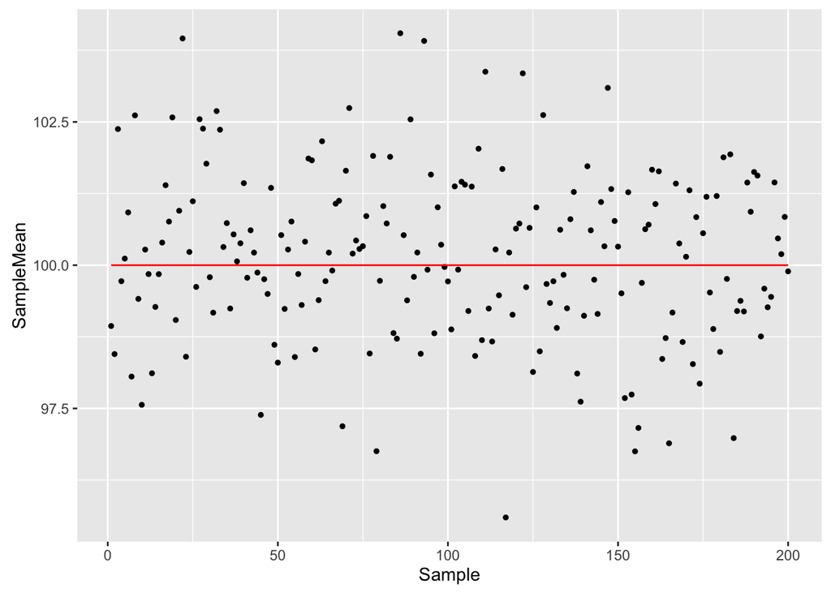

```r
# put your R code here inside the blocks
library("ggplot2")
set.seed(1234)
population <- rnorm(n = pop.size, mean = pop.mean, sd = pop.sd)
samplemean <- numeric(num.of.samples)
samplesd <- numeric(num.of.samples)

for (i in 1:num.of.samples) {
samp <- sample(population,size = sample.size)
samplemean[i] <- mean(samp)
samplesd[i] <- sd(samp)
}

# compare to theoretical values
  # compare sample mean with theoretical value by scatter plot
scatterplot0 <- ggplot() + geom_point(aes(x = 1:num.of.samples, y = samplemean), size = 1) + scale_x_continuous("Sample") + scale_y_continuous("SampleMean")
scatterplot1 <- scatterplot0 + geom_line(aes(x = 1:num.of.samples, y=pop.mean), col = "red")
scatterplot1
```

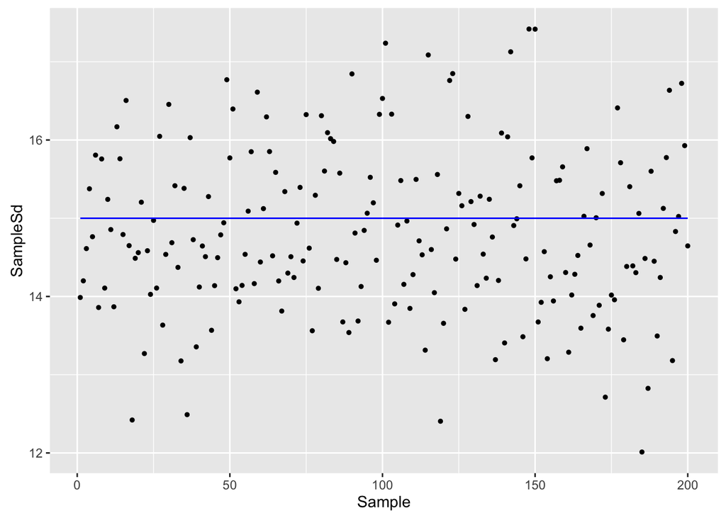

```r
  # compare sample mean with theoretical value by scatter plot
scatterplot2 <- ggplot() + geom_point(aes(x = 1:num.of.samples, y = samplesd), size = 1) + scale_x_continuous("Sample") + scale_y_continuous("SampleSd")
scatterplot3 <- scatterplot2 + geom_line(aes(x = 1:num.of.samples, y=pop.sd), col = "blue")
scatterplot3
```